# 911 Calls -Data Capstone Project

##### Note : This is case study performed under the guidance of Jose Portilla; while undergoing his one of the course on Udemy

For this capstone project we will be analyzing some 911 call data from [Kaggle](https://www.kaggle.com/mchirico/montcoalert). The data contains the following fields:

- lat : String variable, Latitude
- lng: String variable, Longitude
- desc: String variable, Description of the Emergency Call
- zip: String variable, Zipcode
- title: String variable, Title
- timeStamp: String variable, YYYY-MM-DD HH:MM:SS
- twp: String variable, Township
- addr: String variable, Address
- e: String variable, Dummy variable (always 1)

## Importing the Required Libraries , Data and Exploring the Data

```python
import numpy as np
import pandas as pd
```

```python
import matplotlib.pyplot as plt
import seaborn as sns
sns.set_style('whitegrid')
%matplotlib inline
```

**Reading in the csv file as a dataframe called df**

```python
df = pd.read_csv('911.csv')
```

**Checking the info() of the df**

```python
df.info()
```

```
<class 'pandas.core.frame.DataFrame'>
RangeIndex: 99492 entries, 0 to 99491
Data columns (total 9 columns):
lat          99492 non-null float64
lng          99492 non-null float64
desc         99492 non-null object
zip          86637 non-null float64
title        99492 non-null object
timeStamp    99492 non-null object
twp          99449 non-null object
addr         98973 non-null object
e            99492 non-null int64
dtypes: float64(3), int64(1), object(5)
memory usage: 6.8+ MB
```

**First Three Rows of Data**

```python
df.head(3)
```

|  | lat | lng | desc | zip | title | timeStamp | twp | addr | e |
| --- | --- | --- | --- | --- | --- | --- | --- | --- | --- |
| 0 | 40.297876 | -75.581294 | REINDEER CT & DEAD END; NEW HANOVER; Station ... | 19525.0 | EMS: BACK PAINS/INJURY | 2015-12-10 17:40:00 | NEW HANOVER | REINDEER CT & DEAD END | 1 |
| 1 | 40.258061 | -75.264680 | BRIAR PATH & WHITEMARSH LN; HATFIELD TOWNSHIP... | 19446.0 | EMS: DIABETIC EMERGENCY | 2015-12-10 17:40:00 | HATFIELD TOWNSHIP | BRIAR PATH & WHITEMARSH LN | 1 |
| 2 | 40.121182 | -75.351975 | HAWS AVE; NORRISTOWN; 2015-12-10 @ 14:39:21-St... | 19401.0 | Fire: GAS-ODOR/LEAK | 2015-12-10 17:40:00 | NORRISTOWN | HAWS AVE | 1 |

## Questions from Case Study

**1. What are the top 5 zipcodes for 911 calls?**

```python
df['zip'].value_counts().head(5)
```

```
19401.0    6979
19464.0    6643
19403.0    4854
19446.0    4748
19406.0    3174
Name: zip, dtype: int64
```

**2. What are the top 5 townships (twp) for 911 calls?**

```python
df['twp'].value_counts().head(5)
```

```
LOWER MERION    8443
ABINGTON        5977
NORRISTOWN      5890
UPPER MERION    5227
CHELTENHAM      4575
Name: twp, dtype: int64
```

**3. Take a look at the 'title' column, how many unique title codes are there?**

```python
df['title'].nunique()
```

```
110
```

## Creating new feature

```python
df['Reason'] = df['title'].apply(lambda title: title.split(':')[0])
```

**Question: What is the most common Reason for a 911 call based off of this new column?**

```python
df['Reason'].value_counts()
```

```
EMS        48877
Traffic    35695
Fire       14920
Name: Reason, dtype: int64
```

**Using seaborn to create a countplot of 911 calls by Reason.**

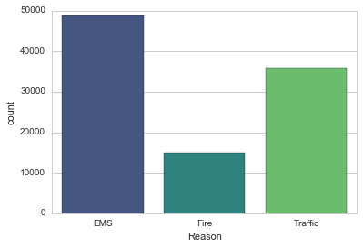

```python
sns.countplot(x='Reason',data=df,palette='viridis')
```

**Question: What is the data type of the objects in the timeStamp column?**

```python
type(df['timeStamp'].iloc[0])
```

```
str
```

**As we can see that these timestamps are still strings. Using pd.to_datetime to convert the column from strings to DateTime objects.**

```python
df['timeStamp'] = pd.to_datetime(df['timeStamp'])
```

```python
df['Hour'] = df['timeStamp'].apply(lambda time: time.hour)
df['Month'] = df['timeStamp'].apply(lambda time: time.month)
df['Day of Week'] = df['timeStamp'].apply(lambda time: time.dayofweek)
```

**Notice how the Day of Week is an integer 0-6. Use the .map() with this dictionary to map the actual string names to the day of the week:**

```
dmap = {0:'Mon',1:'Tue',2:'Wed',3:'Thu',4:'Fri',5:'Sat',6:'Sun'}
```

```python
dmap = {0:'Mon',1:'Tue',2:'Wed',3:'Thu',4:'Fri',5:'Sat',6:'Sun'}
```

```python
df['Day of Week'] = df['Day of Week'].map(dmap)
```

**Using seaborn to create a countplot of the Day of Week column with the hue based off of the Reason column.**

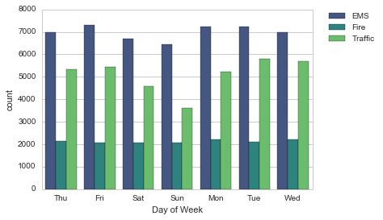

```python
sns.countplot(x='Day of Week',data=df,hue='Reason',palette='viridis')

# To relocate the legend
plt.legend(bbox_to_anchor=(1.05, 1), loc=2, borderaxespad=0.)
```

**Same as above for Month:**

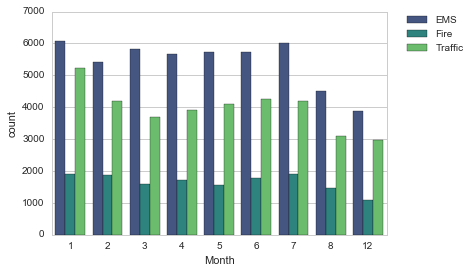

```python
sns.countplot(x='Month',data=df,hue='Reason',palette='viridis')

# To relocate the legend
plt.legend(bbox_to_anchor=(1.05, 1), loc=2, borderaxespad=0.)
```

**Something strange about the Plot: It is missing some months! 9,10, and 11 are not there.**

```python
byMonth = df.groupby('Month').count()
byMonth.head()
```

| Month | lat | lng | desc | zip | title | timeStamp | twp | addr | e | Reason | Hour | Day of Week |
| --- | --- | --- | --- | --- | --- | --- | --- | --- | --- | --- | --- | --- |
| 1 | 13205 | 13205 | 13205 | 11527 | 13205 | 13205 | 13203 | 13096 | 13205 | 13205 | 13205 | 13205 |
| 2 | 11467 | 11467 | 11467 | 9930 | 11467 | 11467 | 11465 | 11396 | 11467 | 11467 | 11467 | 11467 |
| 3 | 11101 | 11101 | 11101 | 9755 | 11101 | 11101 | 11092 | 11059 | 11101 | 11101 | 11101 | 11101 |
| 4 | 11326 | 11326 | 11326 | 9895 | 11326 | 11326 | 11323 | 11283 | 11326 | 11326 | 11326 | 11326 |
| 5 | 11423 | 11423 | 11423 | 9946 | 11423 | 11423 | 11420 | 11378 | 11423 | 11423 | 11423 | 11423 |

**Creating a plot off of the dataframe indicating the count of calls per month.**

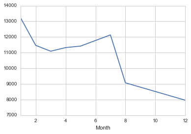

```python
# Could be any column
byMonth['twp'].plot()
```

**Using seaborn's lmplot() to create a linear fit on the number of calls per month.**

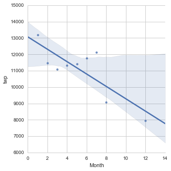

```python
sns.lmplot(x='Month',y='twp',data=byMonth.reset_index())
```

* *Visualizing 911 calls data based on timestamp*

```python
df['Date']=df['timeStamp'].apply(lambda t: t.date())
```

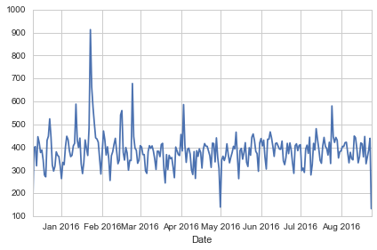

```python
df.groupby('Date').count()['twp'].plot()
plt.tight_layout()
```

**Recreate this plot but creating 3 separate plots with each plot representing a Reason for the 911 call**

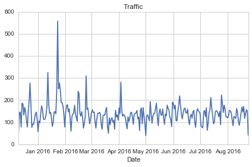

```python
df[df['Reason']=='Traffic'].groupby('Date').count()['twp'].plot()
plt.title('Traffic')
plt.tight_layout()
```

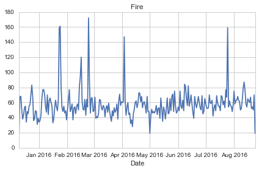

```python
df[df['Reason']=='Fire'].groupby('Date').count()['twp'].plot()
plt.title('Fire')
plt.tight_layout()
```

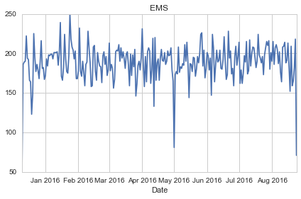

```python
df[df['Reason']=='EMS'].groupby('Date').count()['twp'].plot()
plt.title('EMS')
plt.tight_layout()
```

# End of Exploring the Data!